# Отчет по практическому заданию курса ППП

(Прим. разбиение по пунктам между нами (выполняющими) - условное. Все этапы делались совместно.)

## 1. Анализ стационарности в широком смысле временного ряда (Алияров Руслан)

### Определение

Ряд называется стационарным в широком смысле слова, если выполняются следующие условия:

а) математическое ожидание является константой (не зависит от времени);

б) дисперсия является константой (не зависит от времени);

в) Ковариационная функция функционально зависит только от разности аргументов.

То есть под стационарностью ряда понимают неизменность со временем его характеристик.

### График временного ряда со скользящими средними

Ниже представлен график временного ряда и скользящих средних SMA (красный график), WMA (зеленый график), EMA (синий график):

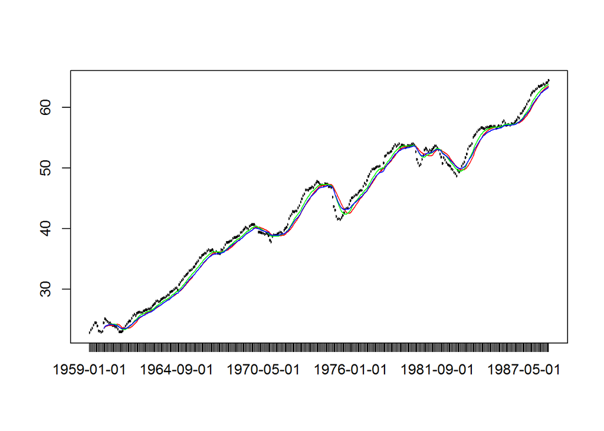

Из графика можно сделать очевидный вывод, что временной ряд не является стационарным, так как он возрастает и его дисперсия изменяется с течением времени. Скользящие средние стационарного ряда должны быть близки к горизонтальной линии.

Нестационарность временного ряда подтверждает и тест Дики-Фуллера:

```
##
##  Augmented Dickey-Fuller Test
##
## data:  trainingData$Value
## Dickey-Fuller = -3.2505, Lag order = 7, p-value = 0.07962
## alternative hypothesis: stationary
```

Если p-value > 0.05, то временной ряд не является стационарным.

## 2. Разложение временного ряда (Полушкин Андрей)

### Разложение в соответствии с аддитивной моделью

Аддитивной моделью временного ряда называют сумму трендовой, сезональной и остаточной составляющих. На графике ниже представлено разложение временного ряда на тренд (trend), сезонность (seasonal) и остаток (random), соответствующее аддитивной модели.

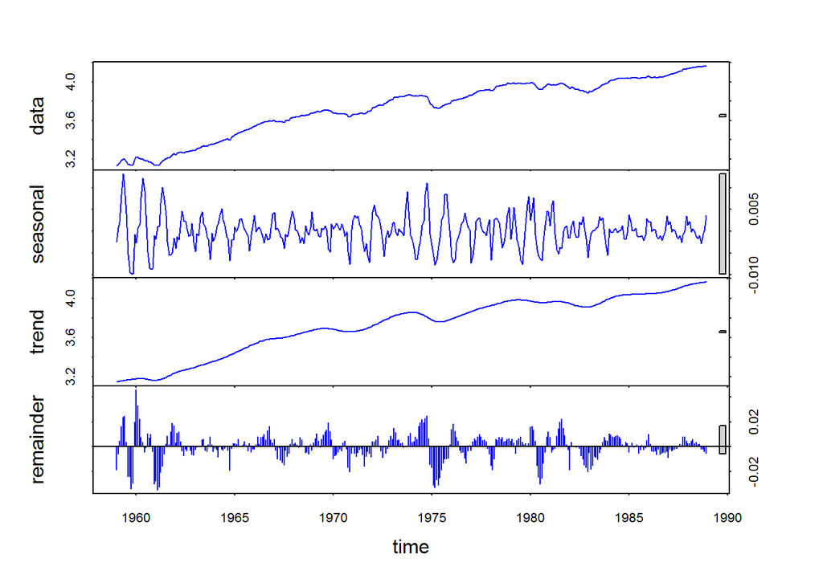

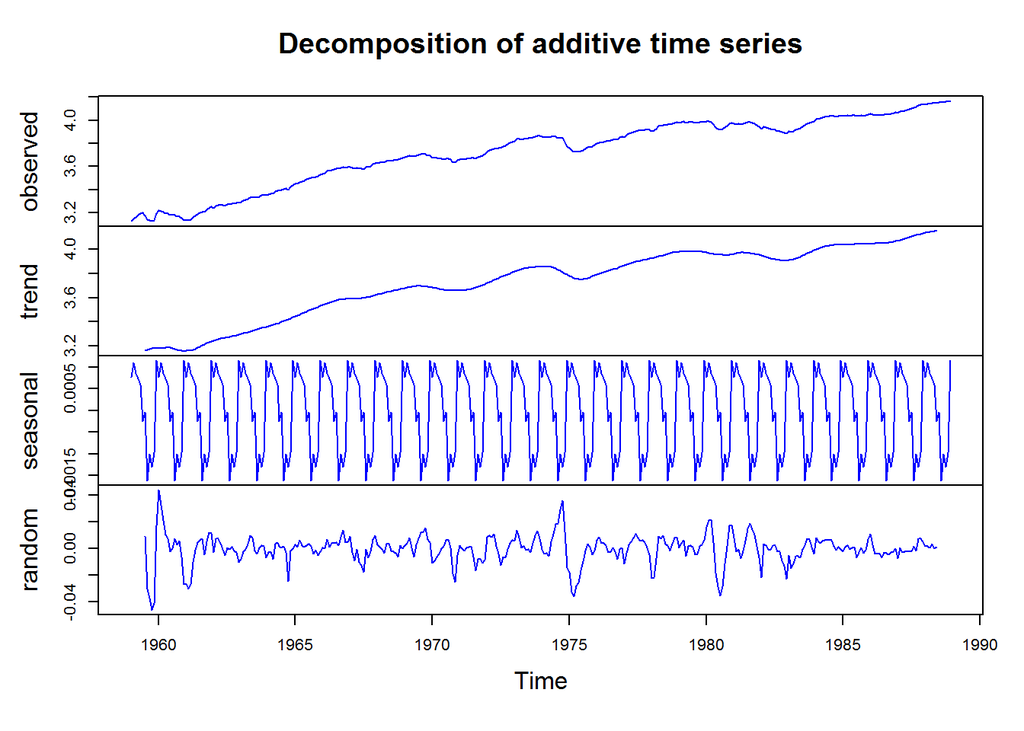

Проверим полученные временные ряды на стационарность.

1. Тренд:

```
##
##  Augmented Dickey-Fuller Test
##
## data:  na.omit(tsDecomposition$trend)
## Dickey-Fuller = -1.9358, Lag order = 7, p-value = 0.6039
## alternative hypothesis: stationary
```

Тест Дики-Фуллера показал, что тренд аддитивной модели не является стационарным временным рядом.Что является очевидным следствием из нестационарности исходного временного ряда.

2. Сезональность:

```
##
##  Augmented Dickey-Fuller Test
##
## data:  na.omit(tsDecomposition$seasonal)
## Dickey-Fuller = -36.075, Lag order = 7, p-value = 0.01
## alternative hypothesis: stationary
```

3. Остаток:

```
##
##  Augmented Dickey-Fuller Test
##
## data:  na.omit(tsDecomposition$random)
## Dickey-Fuller = -7.3136, Lag order = 7, p-value = 0.01
## alternative hypothesis: stationary
```

### Разложение в соответствии с мультипликативной моделью

Мудьтипликативной моделью временного ряда называют произведение трендовой, сезональной и остаточной составляющих. На графике ниже представлено разложение временного ряда на тренд (trend), сезонность (seasonal) и остаток (random), соответствующее мультипликативной модели.

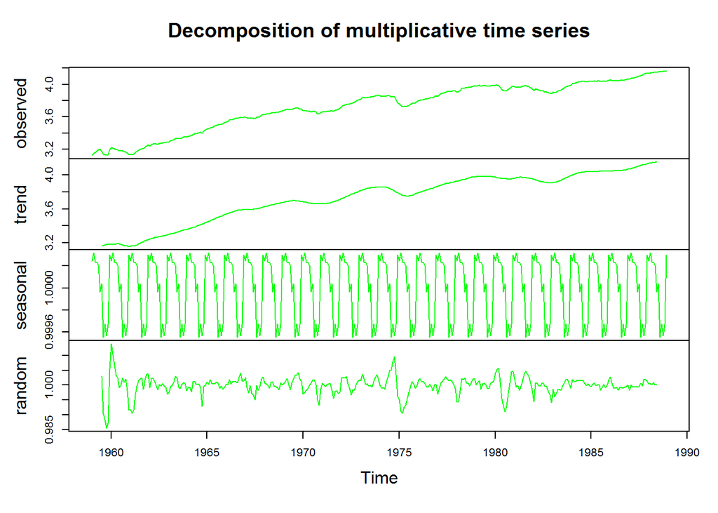

Проверим полученные временные ряды на стационарность.

1. Тренд:

```
##
##  Augmented Dickey-Fuller Test
##
## data:  na.omit(tsDecompositionMulti$trend)
## Dickey-Fuller = -1.9358, Lag order = 7, p-value = 0.6039
## alternative hypothesis: stationary
```

Тест Дики-Фуллера показал, что тренд мультипликативной модели не является стационарным временным рядом.Что является очевидным следствием из нестационарности исходного временного ряда.

2. Сезональность:

```
##
##  Augmented Dickey-Fuller Test
##
## data:  na.omit(tsDecompositionMulti$seasonal)
## Dickey-Fuller = -33.58, Lag order = 7, p-value = 0.01
## alternative hypothesis: stationary
```

3. Остаток:

```
##
##  Augmented Dickey-Fuller Test
##
## data:  na.omit(tsDecompositionMulti$random)
## Dickey-Fuller = -7.4577, Lag order = 7, p-value = 0.01
## alternative hypothesis: stationary
```

## Прогнозирование на основе тренировачных данных

### Интегрированность порядка k

Временной ряд X(t) называется интегрированным порядка k, если разности ряда k-го порядка (delta)^k x(t) - является стационарным, в то время как разности менньшего порядка не являются стационарными относительно тренда.

Как мы заключили из первого пункта, исходный ряд не является стационарным. Поэтому найдем разность первого порядка для исходного ряда:

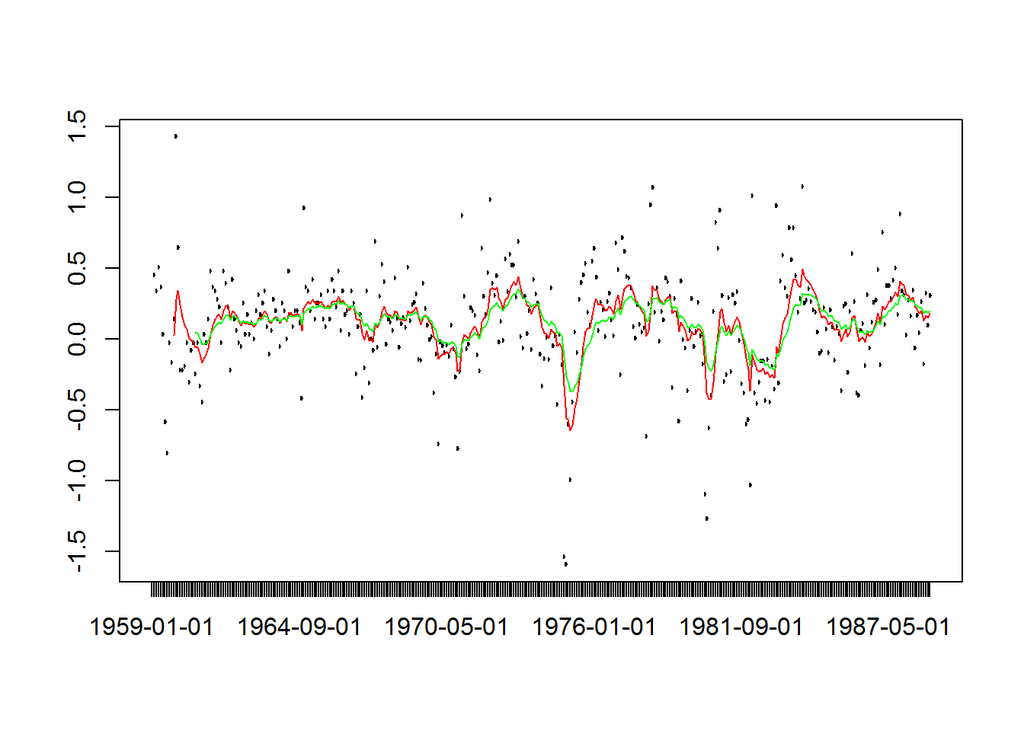

На графике красным и зеленым изображены экспонециальные скользящие средние с парметрами 10 и 20 месяцев соответстветственно.

Из графика можно предположить, что ряд является стацонарным, так как средние идут вдоль горизонтальной прямой, а их колебания не столь сильны. Проверим это предположение тестом Дики-Фуллера:

```
##
##  Augmented Dickey-Fuller Test
##
## data:  test
## Dickey-Fuller = -5.0661, Lag order = 7, p-value = 0.01
## alternative hypothesis: stationary
```

Как видно из результатов теста Дики-Фуллера (p-value < 0.05), временной ряд, составленный из разностей первого порядка, можно считать стационарным. Поэтому исходный временной ряд является итегрированным первого порядка.

### Применение модели ARIMA (Байрамкулов Аслан)

Модели ARIMA(p, d, q) применяются только к стационарным временным рядам, по этой причине вопользуемся результатами предыдущего пункта: d - один из параметров модели ARIMA (порядок интегрированности исходного ряда) уже найден и равен 1.

Для выбора p и q построим функции автокорреляции и частичной автокорреляции временного ряда, полученного после разбиения порядка один:

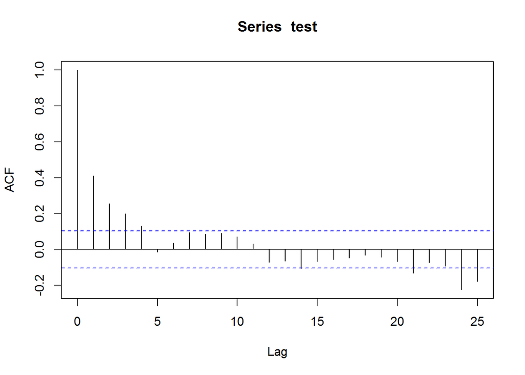

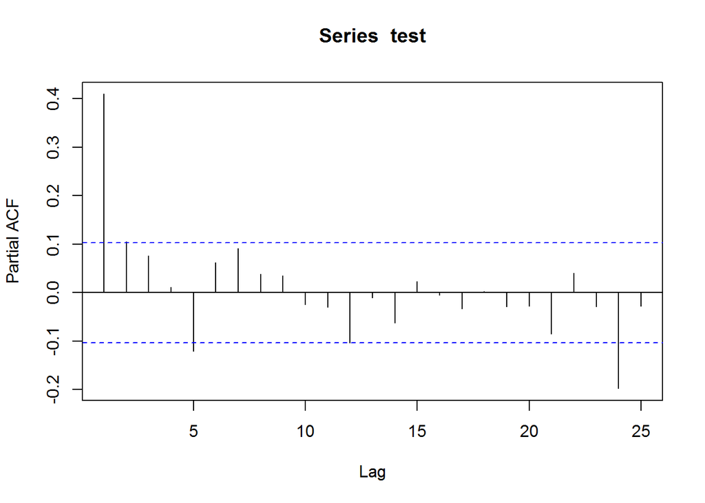

Исходя из проведенных исследований автокорреляции, выберем значения параметров p и q модели ARIMA. Возможны 3 варианта:

1)Arima(2, 1, 0);

2)Arima(0, 1, 4);

3)Arima(p, 1, q).

По принципу наименьшего выбираем модель Arima с минимальным числом параметров, то есть Arima(2, 1, 0):

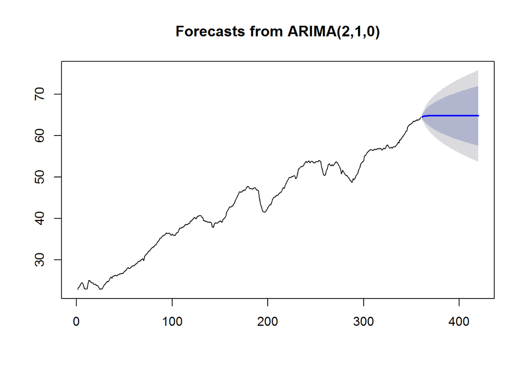

Теперь определим достоверность прогноза:

```
## [1] -0.08292902
```

Аналогичные действия проведем для модели ARIMA(0, 1, 4)

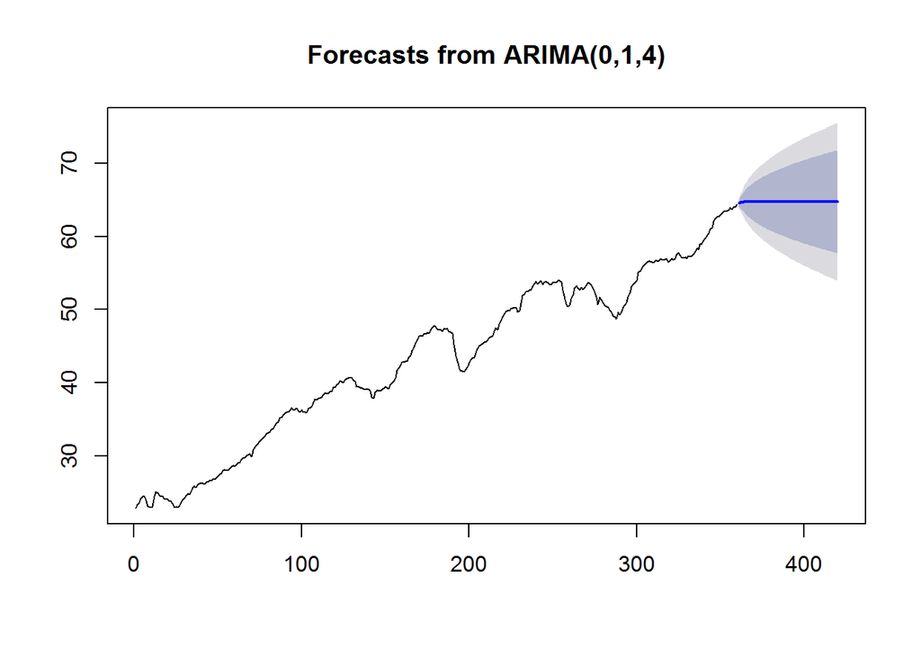

Теперь определим достоверность прогноза:

```
## [1] -0.09951206
```

Сравним модели ARIMA(2, 1, 0) и ARIMA(0, 1, 4) по критерию Акаике:

```
##               df      AIC
## arimaModel210  3 258.5099
## arimaModel014  5 253.3399
```

Чем меньше значение коэффициента Акаике, тем лучше модель. Поэтому стоит выбрать модель ARIMA(0, 1, 4).

Также можно подключить в модели ARIMA линейный дрейф. Тогда прогноз будет демонстрировать и тренд:

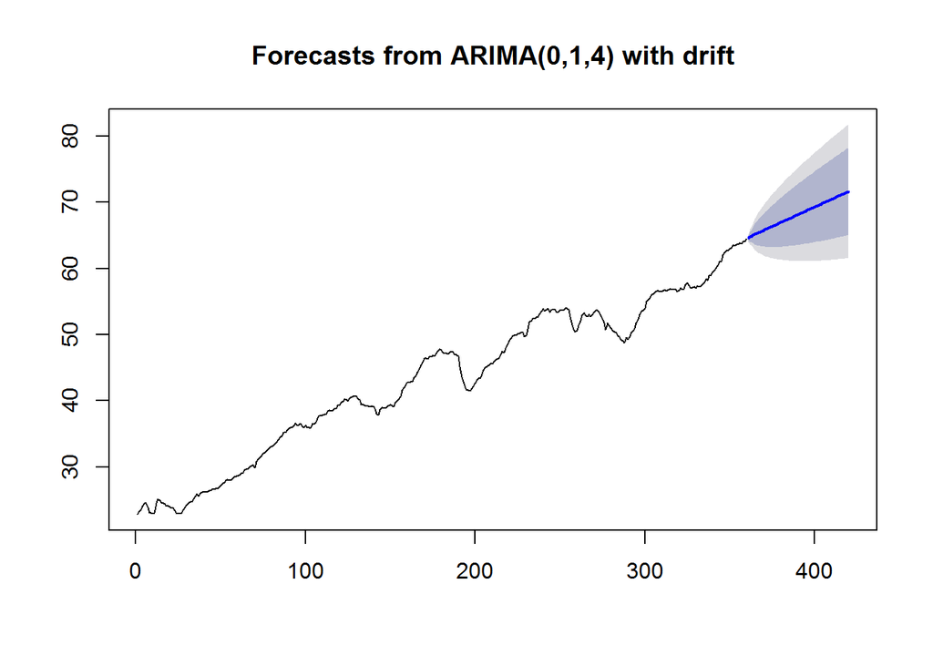

Однако, оценка r2 score ухудшается:

```
## [1] -3.227064
```

И наконец значения коэффициента Акаике:

```
## [1] 245.0053
```